# chap8_axes

J.H AHN

2022 1 10

### 8.1 Swapping X- and Y-Axes

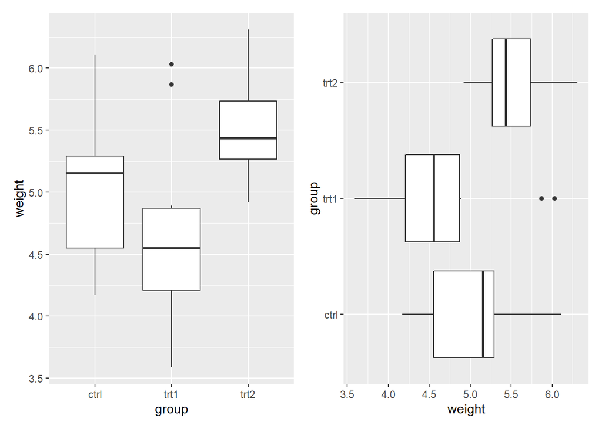

```r
fig_8011 <-
  PlantGrowth %>%
  ggplot(aes(x = group, y = weight)) +
  geom_boxplot()

fig_8012 <-
  PlantGrowth %>%
  ggplot(aes(x = group, y = weight)) +
  geom_boxplot() +
  coord_flip()

fig_8011 + fig_8012
```

때로 축을 바꾸면 아이템의 순서를 거꾸로 배치하여야 할 때가 있다.  
만약 x변수가 factor라면 `scale_x_discrete(limits=rev(levels(...)))`를 사용하여 순서를 바꿀 수 있다.

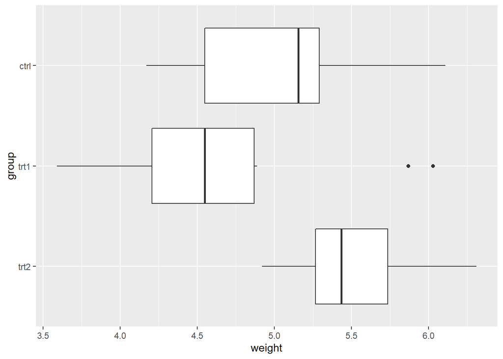

```r
PlantGrowth %>%
  ggplot(aes(x = group, y = weight)) +
  geom_boxplot() +
  coord_flip() +
  scale_x_discrete(limits=rev(levels(PlantGrowth$group)))
```

### 8.2 Setting the range of a continuous axis

**xlim**과 **ylim**을 사용하여 연속형 변수가 사용되는 축의 최대, 최솟값을 지정할 수 있다.

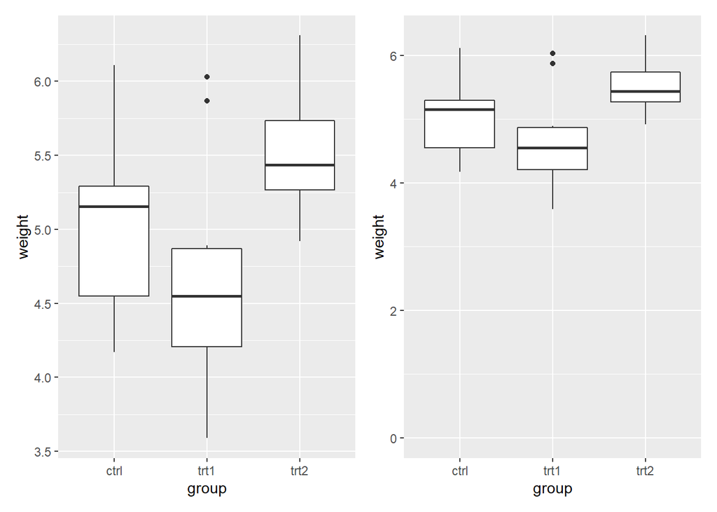

```r
fig_8031 <-
  PlantGrowth %>%
  ggplot(aes(x = group, y = weight)) +
  geom_boxplot()

fig_8032 <-
  PlantGrowth %>%
  ggplot(aes(x = group, y = weight)) +
  geom_boxplot() +
  ylim(0, max(PlantGrowth$weight))

fig_8031 + fig_8032
```

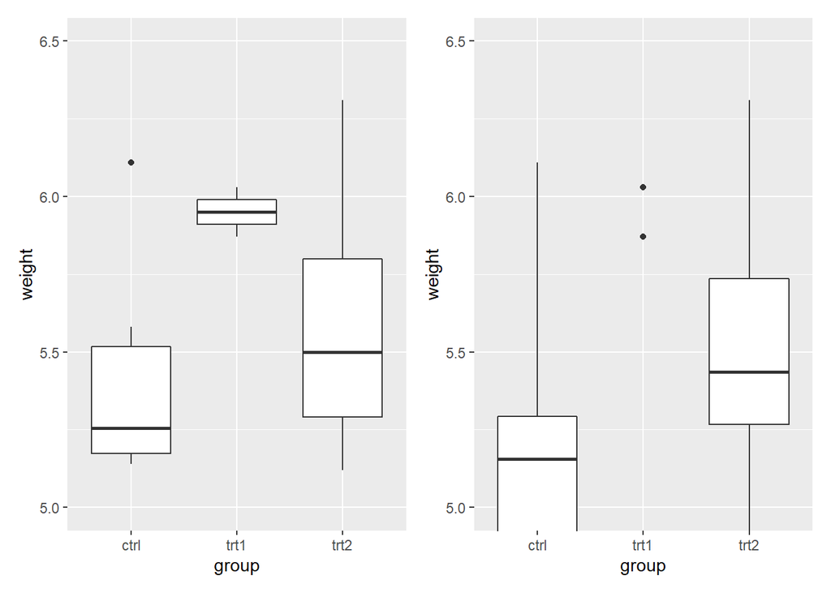

```r
fig_8041 <-
  PlantGrowth %>%
  ggplot(aes(x = group, y = weight)) +
  geom_boxplot() +
  scale_y_continuous(limits = c(5, 6.5))

fig_8042 <-
  PlantGrowth %>%
  ggplot(aes(x = group, y = weight)) +
  geom_boxplot() +
  coord_cartesian(ylim = c(5, 6.5))

fig_8041 + fig_8042
```

범위를 확장하고 싶을 때는 `expande_limits()`를 사용한다.  
**하지만 범위를 줄일 수는 없다.**

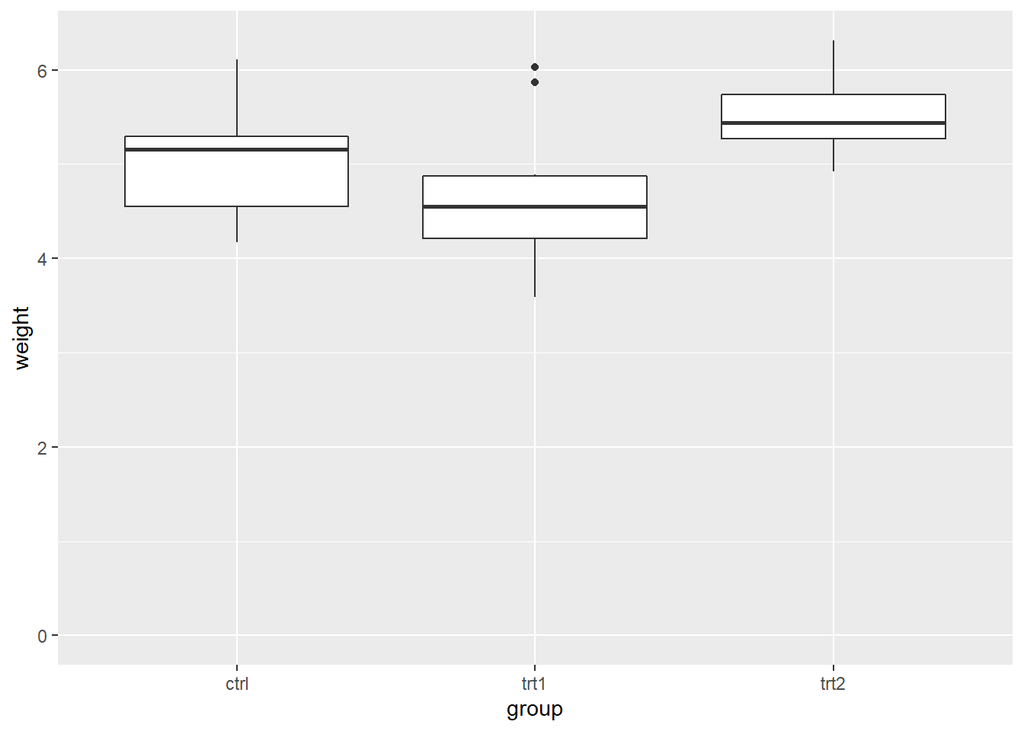

```r
PlantGrowth %>%
  ggplot(aes(x = group, y = weight)) +
  geom_boxplot() +
  expand_limits(y = 0)
```

### 8.3 Reversing a continuous axis

`scale_y_reverse()` 혹은 `scale_x_reverse()`를 사용하면 축방향을 반대로 돌릴 수 있다.

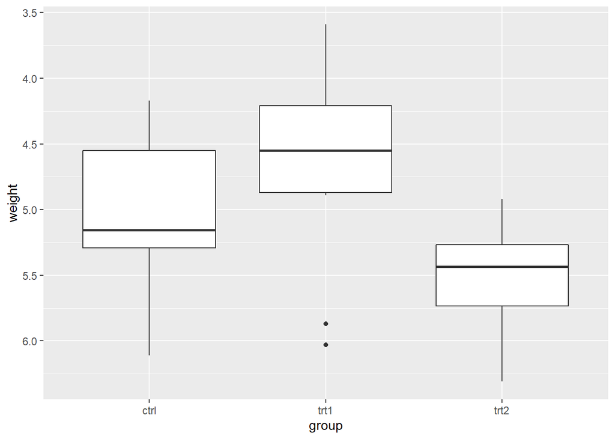

```r
PlantGrowth %>%
  ggplot(aes(x = group, y = weight)) +
  geom_boxplot() +
  scale_y_reverse()
```

`scale_y_reverse()`을 사용하지 않고 유사한 효과를 내려면 아래와 같이 최대, 최솟값의 순서를 바꾸면 된다.

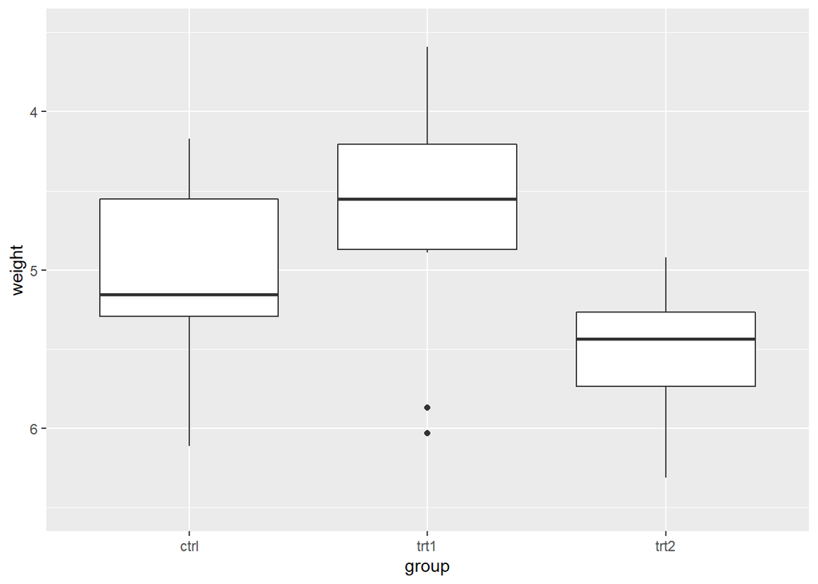

```r
PlantGrowth %>%
  ggplot(aes(x = group, y = weight)) +
  geom_boxplot() +
  ylim(6.5, 3.5)
```

`scale_y_continuous()`처럼 `scale_y_reverse()`는 `ylim()`과 함께 사용할 수 없다. 만약 축을 방향을 바꾸면서 range값을 세팅하고 싶다면 `scale_y_reverse()`안에서 limits을 설정해야 한다.

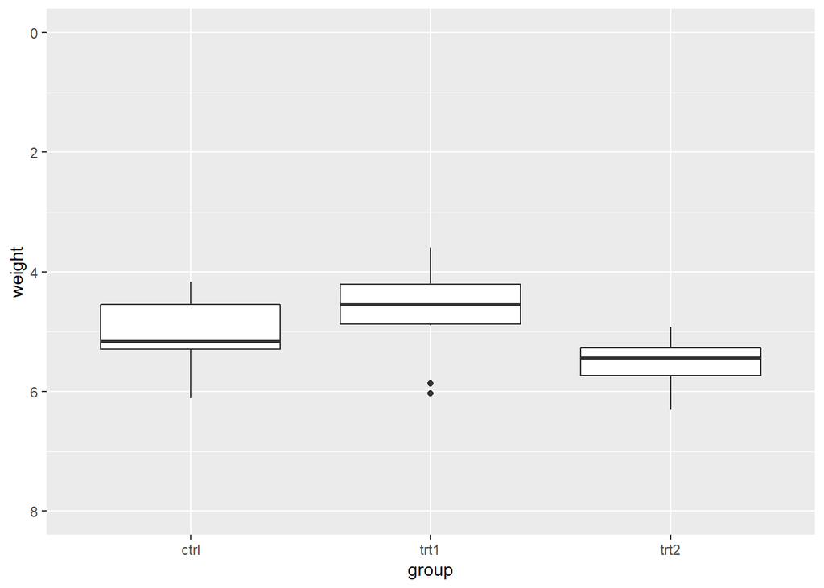

```r
PlantGrowth %>%
  ggplot(aes(x = group, y = weight)) +
  geom_boxplot() +
  scale_y_reverse(limits = c(8,0))
```

### 8.4 Changing the order of items on a categorical axis

범주형, 이산형 변수 축을 순서대로 정렬하기 위해서는 `scale_x_discrete()` 혹은 `scale_y_discrete()`안에 limits을 설정해야 한다.  
순서는 매뉴얼로 정해줘야 하고 원하는 순서대로 벡터 형식으로 입력하면 된다.  
원하는 변수만 보여주고 싶으면 limits에 원하는 변수만 선택한다.

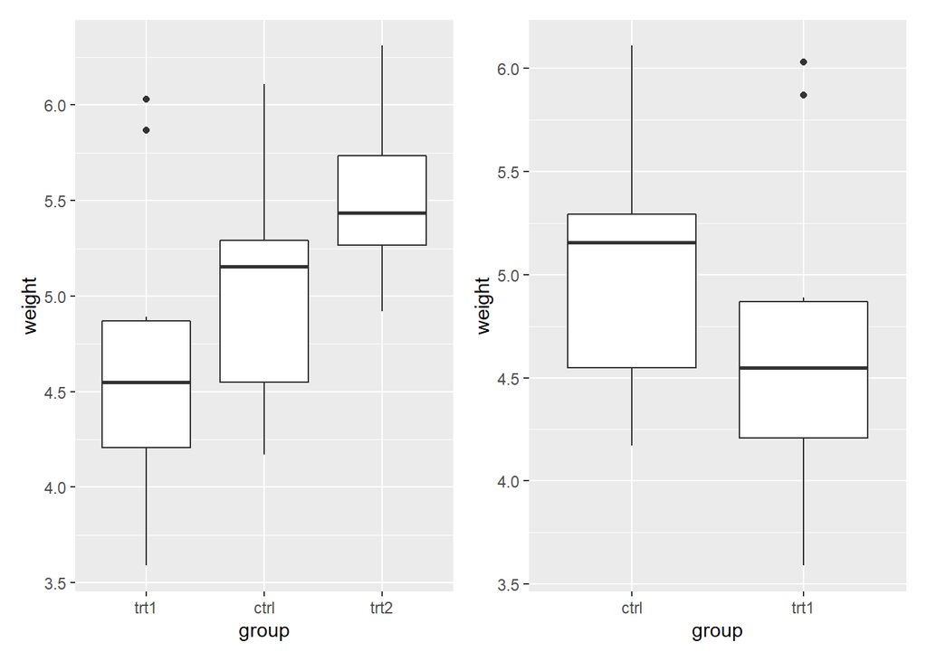

```r
fig_8081 <-
  PlantGrowth %>%
  ggplot(aes(x = group, y = weight)) +
  geom_boxplot() +
  scale_x_discrete(limits = c("trt1", "ctrl", "trt2"))

fig_8082 <-
  PlantGrowth %>%
  ggplot(aes(x = group, y = weight)) +
  geom_boxplot() +
  scale_x_discrete(limits = c("ctrl", "trt1"))

fig_8081 + fig_8082
```

순서를 거꾸로 하고 싶으면 동일하게 `limits = rev(levels(...))`를 사용한다.

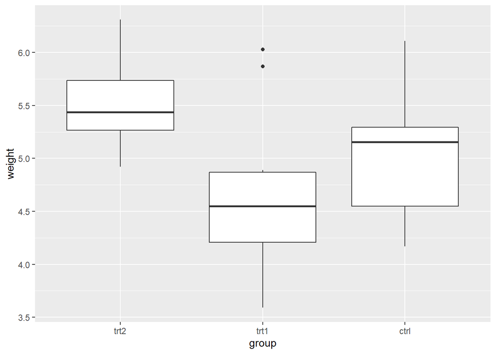

```r
PlantGrowth %>%
  ggplot(aes(x = group, y = weight)) +
  geom_boxplot() +
  scale_x_discrete(limits = rev(levels(PlantGrowth$group)))
```

### 8.5 Setting the scaling ratio of the X- and Y-axes

x축과 Y축의 비율을 정하기 위해서는 `coord_fixed()`를 사용한다.

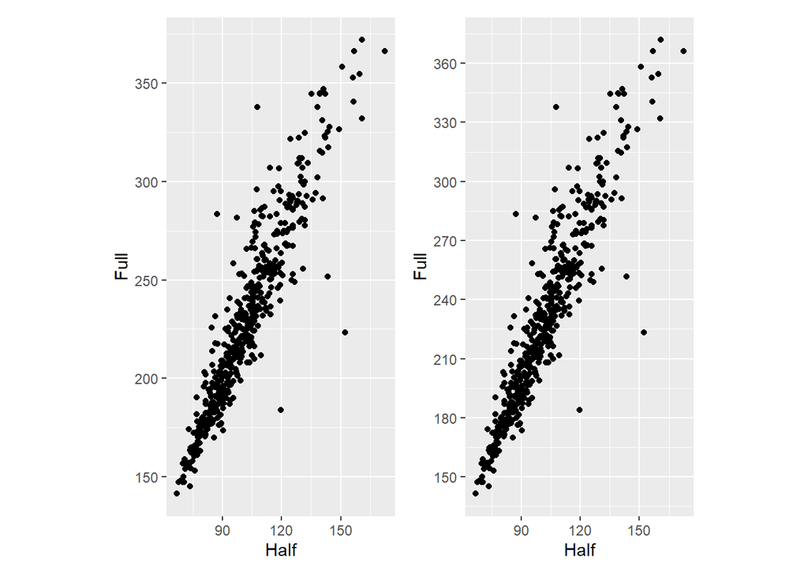

```r
fig_8101 <-
  marathon %>%
  ggplot(aes(x = Half, y = Full)) +
  geom_point() +
  coord_fixed()

fig_8102 <-
  marathon %>%
  ggplot(aes(x = Half, y = Full)) +
  geom_point() +
  coord_fixed() +
  scale_y_continuous(breaks = seq(0, 420, 30)) +
  scale_x_continuous(breaks = seq(0, 420, 30))

fig_8101 + fig_8102
```

x, y축 사이의 비율을 1:1이 아닌 다른 특정한 비율을 넣고 싶다면 ratio 값을 설정한다.

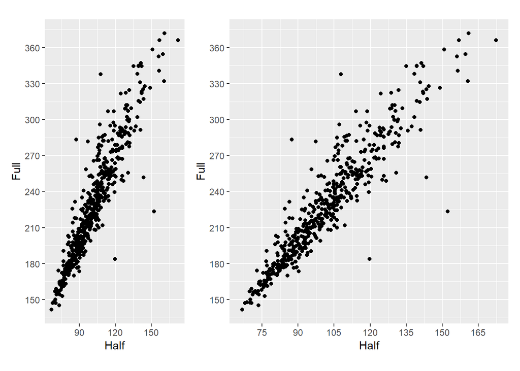

```r
fig_8111 <-
  marathon %>%
  ggplot(aes(x = Half, y = Full)) +
  geom_point() +
  coord_fixed() +
  scale_y_continuous(breaks = seq(0, 420, 30)) +
  scale_x_continuous(breaks = seq(0, 420, 30))

fig_8112 <-
  marathon %>%
  ggplot(aes(x = Half, y = Full)) +
  geom_point() +
  coord_fixed(ratio = 1/2) +
  scale_y_continuous(breaks = seq(0, 420, 30)) +
  scale_x_continuous(breaks = seq(0, 420, 15))

fig_8111 + fig_8112
```

### 8.6 Setting the positions of tick marks

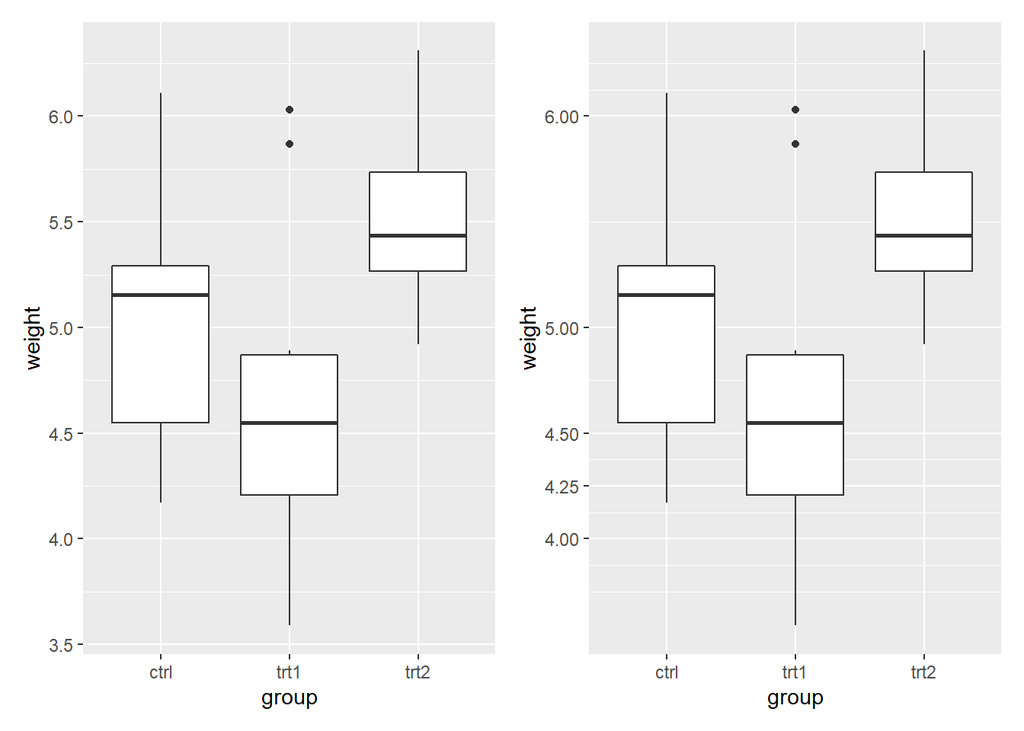

```r
fig_8121 <-
  PlantGrowth %>%
  ggplot(aes(x = group, y = weight)) +
  geom_boxplot()

fig_8122 <-
  PlantGrowth %>%
  ggplot(aes(x = group, y = weight)) +
  geom_boxplot() +
  scale_y_continuous(breaks = c(4, 4.25, 4.5, 5, 6, 8))

fig_8121 + fig_8122
```

이산형 변수가 있는 축에서는 tick mark가 default이다.  
limits에서 명시한 변수만 순서대로 그려진다.  
이 상태에서 breaks를 설정하면 레벨을 바꿀 수 있는 반면 삭제하거나 순서를 바꿀 수는 없게된다.

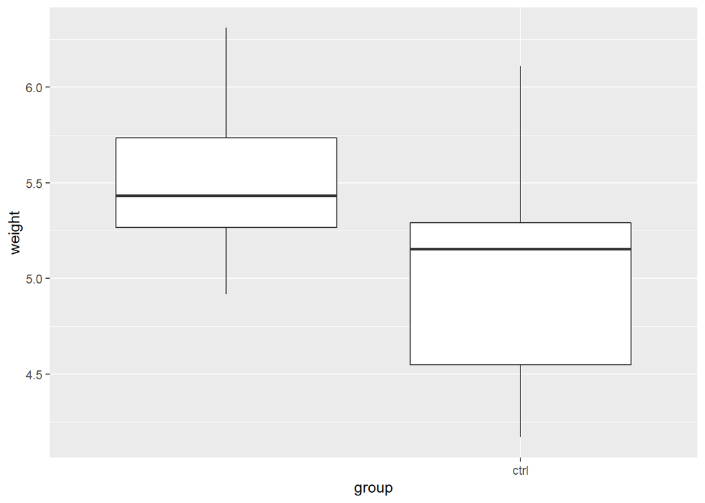

```r
PlantGrowth %>%
  ggplot(aes(x = group, y = weight)) +
  geom_boxplot() +
  scale_x_discrete(limits = c("trt2", "ctrl"), breaks = "ctrl")
```

### 8.7 Removing tick marks and labels

tick labels을 삭제하고 싶을 경우에는 `theme(axis.text.y = element_blank())`를 사용하면 된다.  
이 함수는 연속형 혹은 범주형 변수가 쓰이는 축에 모두 적용된다.

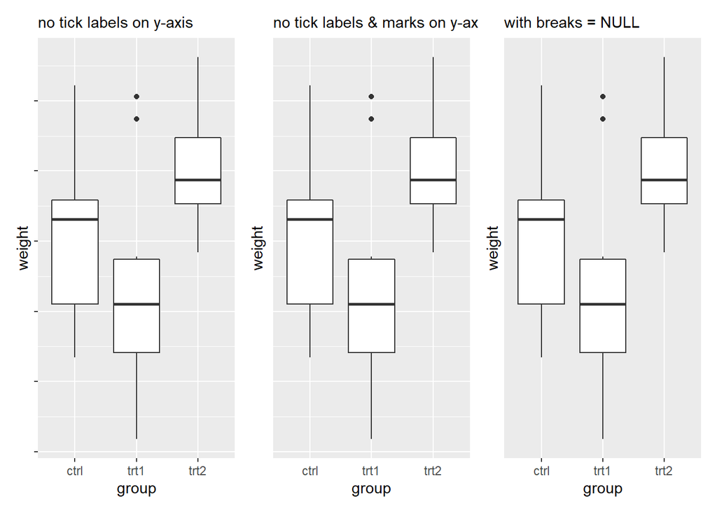

```r
fig_8141 <-
  PlantGrowth %>%
  ggplot(aes(x = group, y = weight)) +
  geom_boxplot() +
  theme(axis.text.y = element_blank()) +
  labs(subtitle = "no tick labels on y-axis")

fig_8142 <-
  PlantGrowth %>%
  ggplot(aes(x = group, y = weight)) +
  geom_boxplot() +
  theme(axis.text.y = element_blank(), axis.ticks = element_blank()) +
  labs(subtitle = "no tick labels & marks on y-axis")

fig_8143 <-
  PlantGrowth %>%
  ggplot(aes(x = group, y = weight)) +
  geom_boxplot() +
  scale_y_continuous(breaks = NULL) +
  labs(subtitle = "with breaks = NULL")

fig_8141 + fig_8142 + fig_8143
```

### 8.8 Changing the text of tick labels

임의의 tick label을 사용하고 싶다면 breaks와 labels를 사용한다.

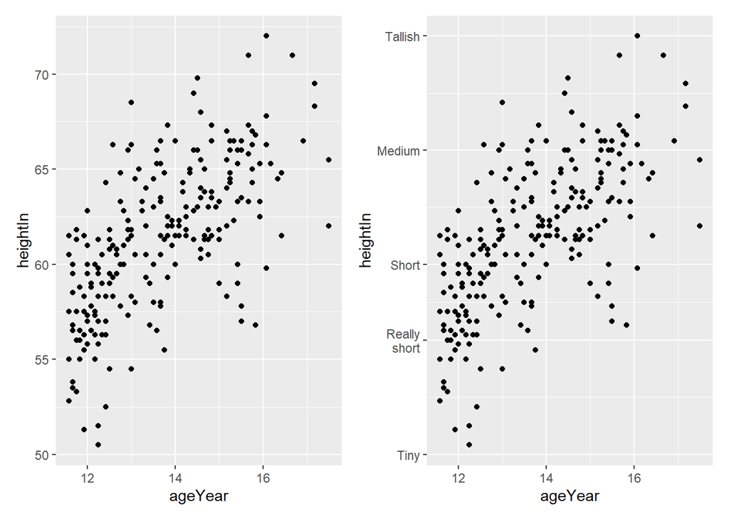

```r
fig_8151 <-
heightweight %>%
  ggplot(aes(x = ageYear, y = heightIn)) +
  geom_point()

fig_8152 <-
heightweight %>%
  ggplot(aes(x = ageYear, y = heightIn)) +
  geom_point() +
  scale_y_continuous(breaks = c(50, 56, 60, 66, 72),
                     labels = c("Tiny", "Really\nshort", "Short", "Medium", "Tallish"))

fig_8151 + fig_8152
```

임의의 label을 모두 입력하기 보다는 하나의 포맷으로 정해두고 넣는 경우가 많다.  
예를 들어 키를 피트(ft)와 인치(in)로 나타낼 때 5’6”와 같이 쓰는 경우다.  
이런 작업을 하기위해서 먼저 포맷을 맞추는 함수를 만들어 입력된 값을 정해진 포맷으로 반환하게 해야 한다.

```r
footinch_formatter <- function(x) {
  foot <- floor(x/12)
  inch <- x %% 12
  return(paste(foot, "'", inch, "\"", sep=""))
}
```

```r
footinch_formatter(56:64)
```

```
## [1] "4'8\""  "4'9\""  "4'10\"" "4'11\"" "5'0\""  "5'1\""  "5'2\""  "5'3\""
## [9] "5'4\""
```

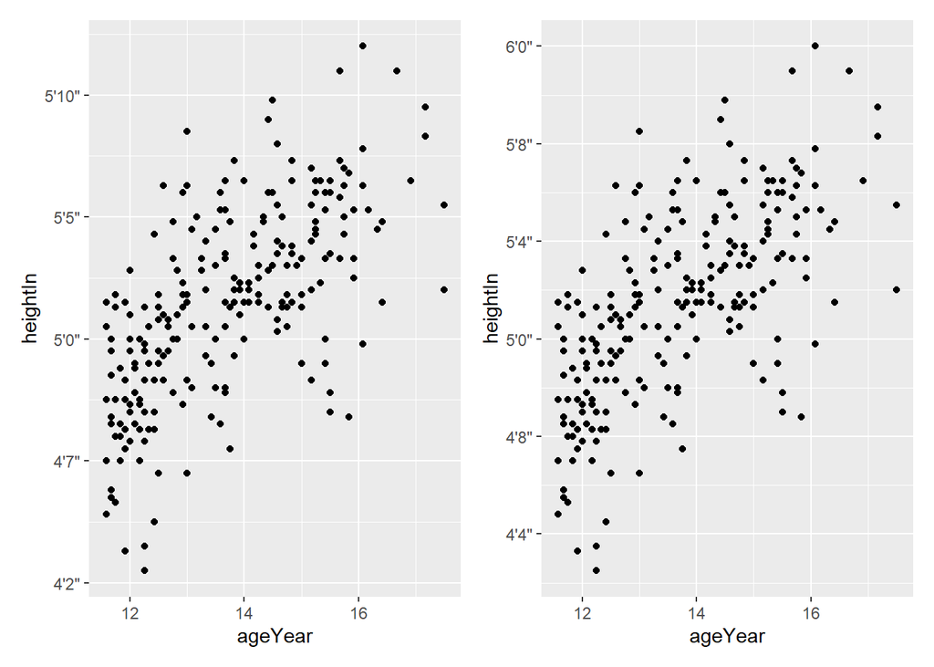

```r
fig_8161 <-
heightweight %>%
  ggplot(aes(x = ageYear, y = heightIn)) +
  geom_point() +
  scale_y_continuous(labels = footinch_formatter)

fig_8162 <-
heightweight %>%
  ggplot(aes(x = ageYear, y = heightIn)) +
  geom_point() +
  scale_y_continuous(breaks = seq(48, 72, 4),
                     labels = footinch_formatter)

fig_8161 + fig_8162
```

또 다른 포맷 변환으로 시간을 HH:MM:SS 형태로 바꾸는 것이 있다. 아래 함수는 분(minute)을 입력하면 시간:분:초의 형태로 변환해 준다.

```r
timeHMS_formatter <- function(x) {
  h <- floor(x/60)
  m <- floor(x %% 60)
  s <- round(60 * (x %% 1))
  lab <- sprintf("%02d:%02d:%02d", h, m, s)
  lab <- gsub("^00:","", lab)
  lab <- gsub("^0","",lab)
  return(lab)
}
```

```r
timeHMS_formatter(c(0.33, 50, 51.25, 59.32, 60, 60.1, 130.23))
```

```
## [1] "0:20"    "50:00"   "51:15"   "59:19"   "1:00:00" "1:00:06" "2:10:14"
```

### 8.9 Changing the appearance of tick labels

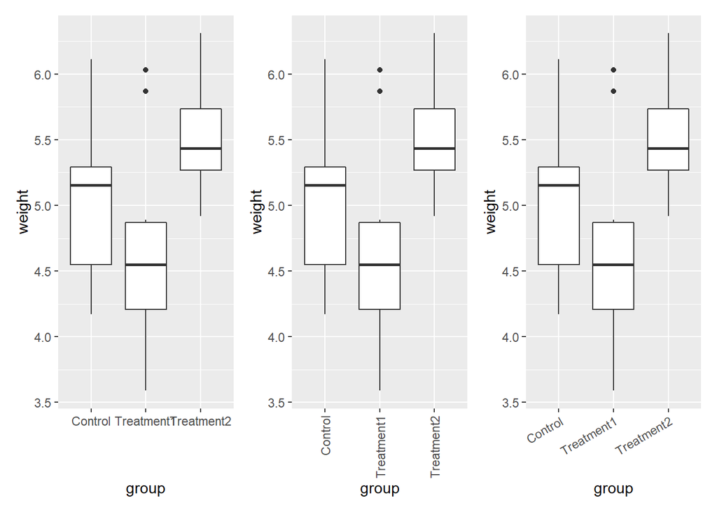

```r
fig_8171 <-
  PlantGrowth %>%
  ggplot(aes(x = group, y = weight)) +
  geom_boxplot() +
  scale_x_discrete(breaks = c("ctrl", "trt1", "trt2"),
                   labels = c("Control", "Treatment1", "Treatment2"))
fig_8172 <-
  PlantGrowth %>%
  ggplot(aes(x = group, y = weight)) +
  geom_boxplot() +
  scale_x_discrete(breaks = c("ctrl", "trt1", "trt2"),
                   labels = c("Control", "Treatment1", "Treatment2")) +
  theme(axis.text.x = element_text(angle = 90, hjust = 1, vjust = 0.5))

fig_8173 <-
  PlantGrowth %>%
  ggplot(aes(x = group, y = weight)) +
  geom_boxplot() +
  scale_x_discrete(breaks = c("ctrl", "trt1", "trt2"),
                   labels = c("Control", "Treatment1", "Treatment2")) +
  theme(axis.text.x = element_text(angle = 30, hjust = 1, vjust = 1))

fig_8171 + fig_8172 + fig_8173
```

글자를 회전시키는 것외에도 size, style(bold/italic/normal), font family(Times, Helvetica) 등을 `element_text()`를 이용하여 변경할 수 있다.  
size를 정할 때 쓴 `rel()`은 theme에서 쓰이는 argument로 다른 글자 대비 상대적인 크기를 얼마로 할지 결정하게 해 준다.

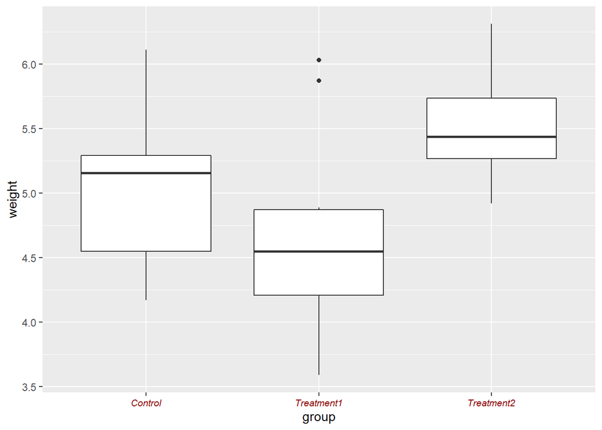

```r
PlantGrowth %>%
  ggplot(aes(x = group, y = weight)) +
  geom_boxplot() +
  scale_x_discrete(breaks = c("ctrl", "trt1", "trt2"),
                   labels = c("Control", "Treatment1", "Treatment2")) +
  theme(axis.text.x = element_text(family = "Times", face = "italic",
                                   color = "#8B0000", size = rel(0.9)))
```

### 8.10 Changing the text of axis labels

축의 text label을 변경하기 위해서는 `xlab()`, `ylab()`을 이용한다.

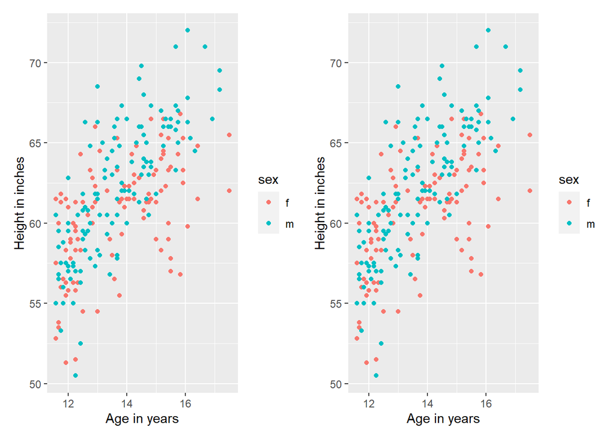

```r
fig_8191 <-
  heightweight %>%
  ggplot(aes(x = ageYear, y = heightIn, color = sex)) +
  geom_point() +
  xlab("Age in years") + ylab("Height in inches")

fig_8192 <-
  heightweight %>%
  ggplot(aes(x = ageYear, y = heightIn, color = sex)) +
  geom_point() +
  labs(x = "Age in years", y = "Height in inches")

fig_8191 + fig_8192
```

다른 방법으로는 `scale_*_continuous()`에 name으로 설정하는 방법이 있다.

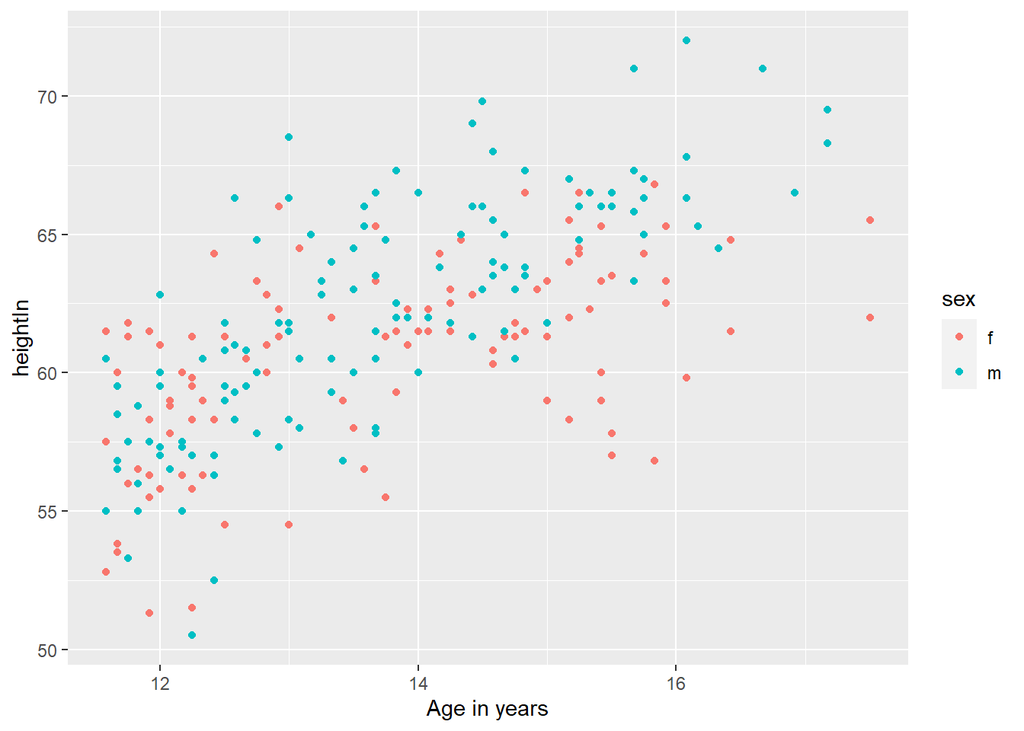

```r
heightweight %>%
  ggplot(aes(x = ageYear, y = heightIn, color = sex)) +
  geom_point() +
  scale_x_continuous(name = "Age in years")
```

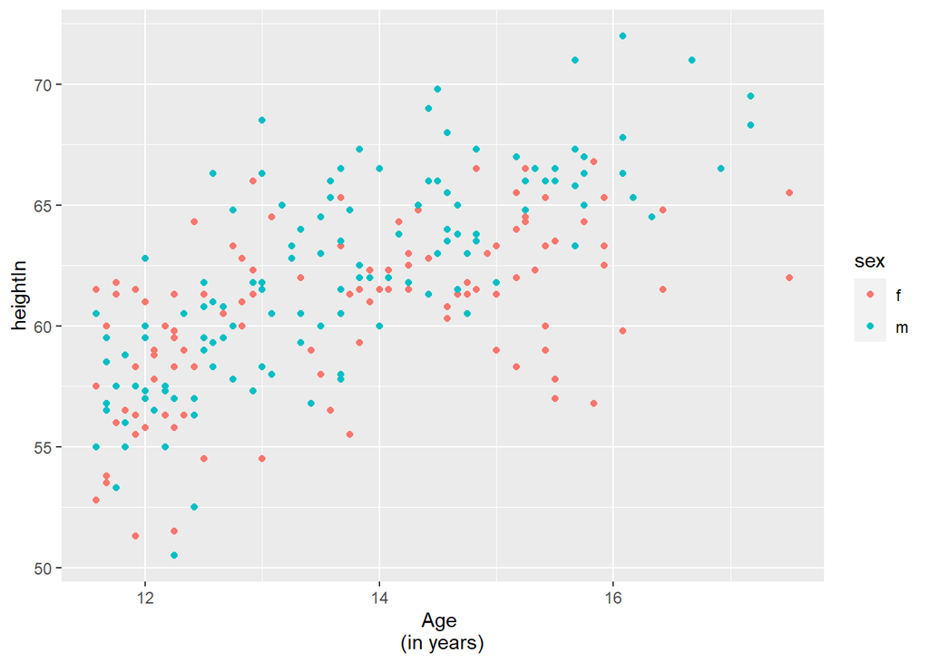

```r
heightweight %>%
  ggplot(aes(x = ageYear, y = heightIn, color = sex)) +
  geom_point() +
  scale_x_continuous(name = "Age \n(in years)")
```

### 8.11 Removing axis labels

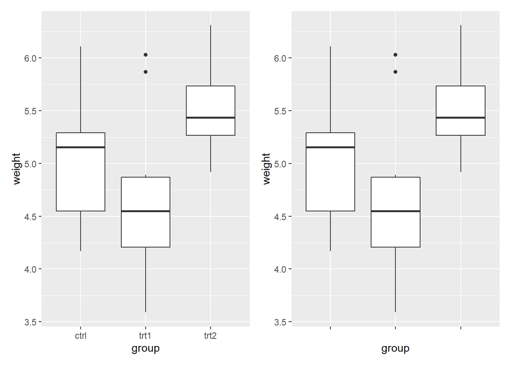

```r
fig_8201 <-
  PlantGrowth %>%
  ggplot(aes(x = group, y = weight)) +
  geom_boxplot()

fig_8202 <-
  PlantGrowth %>%
  ggplot(aes(x = group, y = weight)) +
  geom_boxplot() +
  theme(axis.text.x = element_blank())

fig_8201 + fig_8202
```

label을 지우는 다른 방법으로는 빈 값을 넣는 방법이 있다.  
하지만 이렇게 label을 지우면 원래 글자가 있던 자리의 공간이 글자가 있을 때와 동일하게 유지한다. 책에는 xlab을 쓸 때와 element_blank()를 쓸 때가 다르다고 되어 있는데 현재 ggplot2에는 같게 나옴.

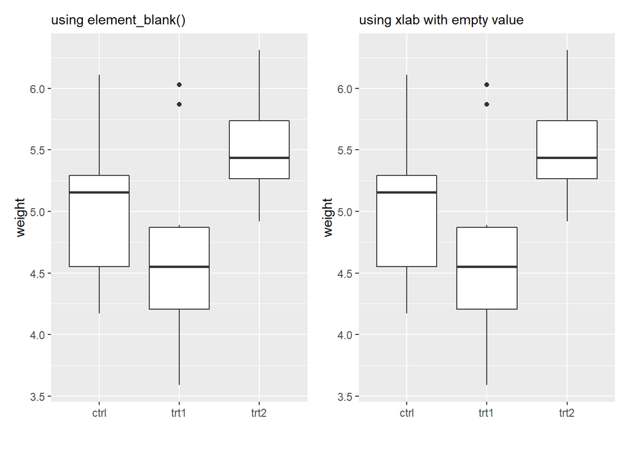

```r
fig_8211 <-
  PlantGrowth %>%
  ggplot(aes(x = group, y = weight)) +
  geom_boxplot() +
  theme(axis.title.x = element_blank()) +
  labs(subtitle = "using element_blank()")

fig_8212 <-
PlantGrowth %>%
  ggplot(aes(x = group, y = weight)) +
  geom_boxplot() +
  xlab("") +
  labs(subtitle = "using xlab with empty value")

fig_8211 + fig_8212
```

### 8.12 Chnaging the apperance of axis labels

축의 label 외형을 바꾸고 싶으면 `axis.title.x()`를 사용

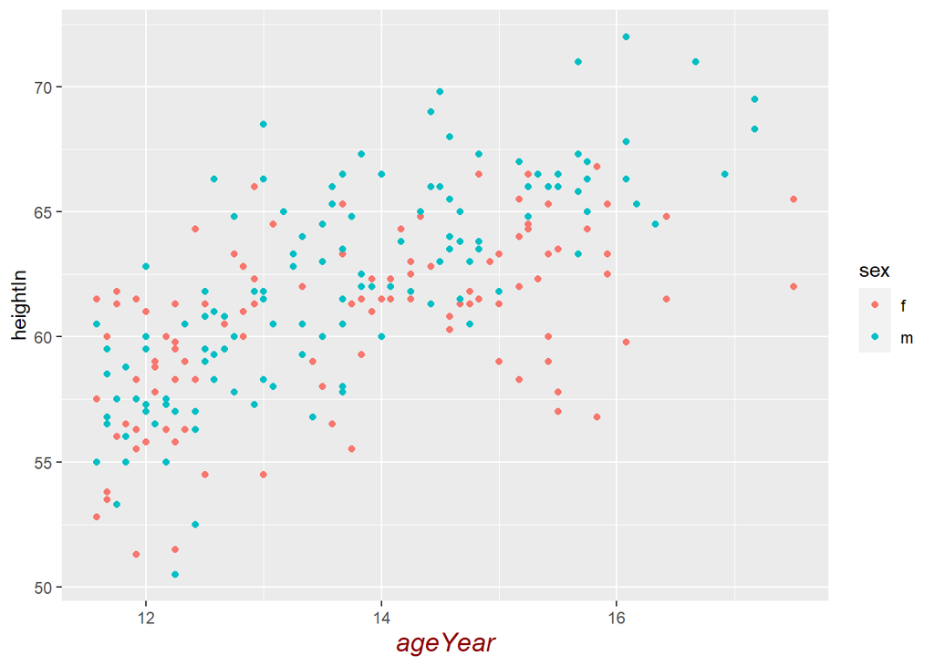

```r
heightweight %>%
  ggplot(aes(x = ageYear, y = heightIn, color = sex)) +
  geom_point() +
  theme(axis.title.x = element_text(face = "italic", color = "#8B0000", size = 14))
```

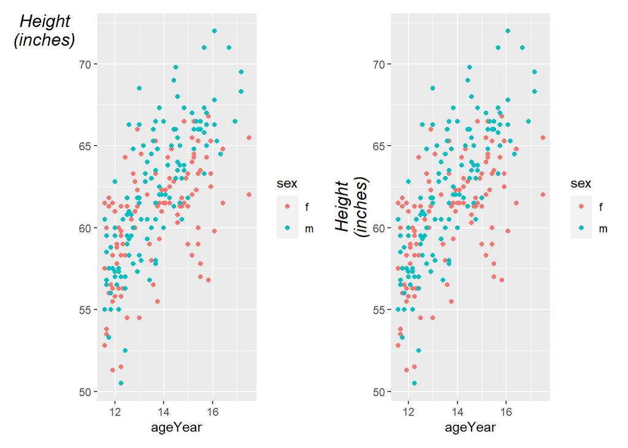

```r
fig_8231 <-
  heightweight %>%
  ggplot(aes(x = ageYear, y = heightIn, color = sex)) +
  geom_point() +
  ylab("Height\n(inches)") +
  theme(axis.title.y = element_text(angle = 0, face = "italic", size = 14))

fig_8232 <-
  heightweight %>%
  ggplot(aes(x = ageYear, y = heightIn, color = sex)) +
  geom_point() +
  ylab("Height\n(inches)") +
  theme(axis.title.y = element_text(angle = 90, face = "italic", size = 14))

fig_8231 + fig_8232
```

### 8.13 Showing lines along the axes

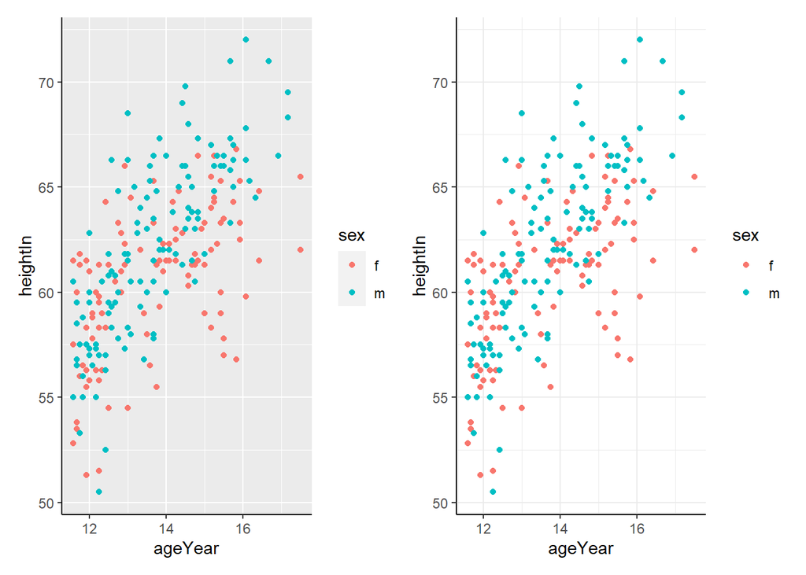

```r
fig_8241 <-
  heightweight %>%
  ggplot(aes(x = ageYear, y = heightIn, color = sex)) +
  geom_point() +
  theme(axis.line = element_line(color = "#000000"))

fig_8242 <-
  heightweight %>%
  ggplot(aes(x = ageYear, y = heightIn, color = sex)) +
  geom_point() +
  theme_bw() +
  theme(panel.border = element_blank(),
        axis.line = element_line(color = "#000000"))

fig_8241 + fig_8242
```

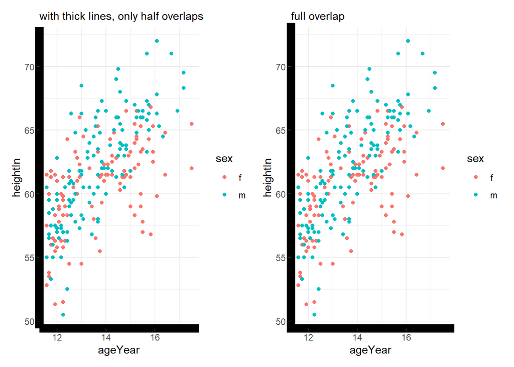

```r
fig_8251 <-
  heightweight %>%
  ggplot(aes(x = ageYear, y = heightIn, color = sex)) +
  geom_point() +
  theme_bw() +
  theme(panel.border = element_blank(),
        axis.line = element_line(color = "#000000", size = 4)) +
  labs(subtitle = "with thick lines, only half overlaps")

fig_8252 <-
  heightweight %>%
  ggplot(aes(x = ageYear, y = heightIn, color = sex)) +
  geom_point() +
  theme_bw() +
  theme(panel.border = element_blank(),
        axis.line = element_line(color = "#000000", size = 4, lineend = "square")) +
  labs(subtitle = "full overlap")

fig_8251 + fig_8252
```

### 8.14 Using a logarithmic axis

```r
Animals
```

```
##                       body  brain
## Mountain beaver      1.350    8.1
## Cow                465.000  423.0
## Grey wolf           36.330  119.5
## Goat                27.660  115.0
## Guinea pig           1.040    5.5
## Dipliodocus      11700.000   50.0
## Asian elephant    2547.000 4603.0
## Donkey             187.100  419.0
## Horse              521.000  655.0
## Potar monkey        10.000  115.0
## Cat                  3.300   25.6
## Giraffe            529.000  680.0
## Gorilla            207.000  406.0
## Human               62.000 1320.0
## African elephant  6654.000 5712.0
## Triceratops       9400.000   70.0
## Rhesus monkey        6.800  179.0
## Kangaroo            35.000   56.0
## Golden hamster       0.120    1.0
## Mouse                0.023    0.4
## Rabbit               2.500   12.1
## Sheep               55.500  175.0
## Jaguar             100.000  157.0
## Chimpanzee          52.160  440.0
## Rat                  0.280    1.9
## Brachiosaurus    87000.000  154.5
## Mole                 0.122    3.0
## Pig                192.000  180.0
```

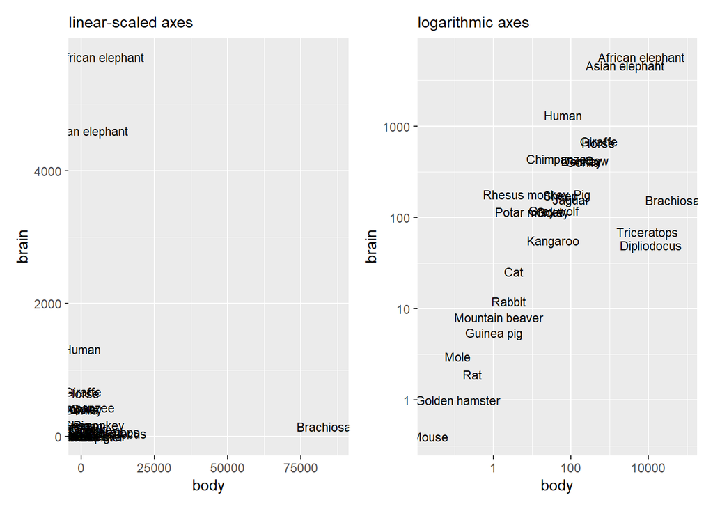

```r
fig_8261 <-
  Animals %>%
  ggplot(aes(x = body, y = brain, label = rownames(Animals))) +
  geom_text(size = 3) +
  labs(subtitle = "linear-scaled axes")

fig_8262 <-
  Animals %>%
  ggplot(aes(x = body, y = brain, label = rownames(Animals))) +
  geom_text(size = 3) +
  scale_x_log10() + scale_y_log10() +
  labs(subtitle = "logarithmic axes")

fig_8261 + fig_8262
```